# Threshold Model Exercise

# Simulating data

Load in the required packages

```r
library(treeplyr)
library(geiger)
library(phytools)
```

```r
library(coda) # This package lets us plot MCMC results nicely, as well as lots of diagnostic features
```

Let’s start by simulating data under multivariate Brownian Motion with a known covariance structure.

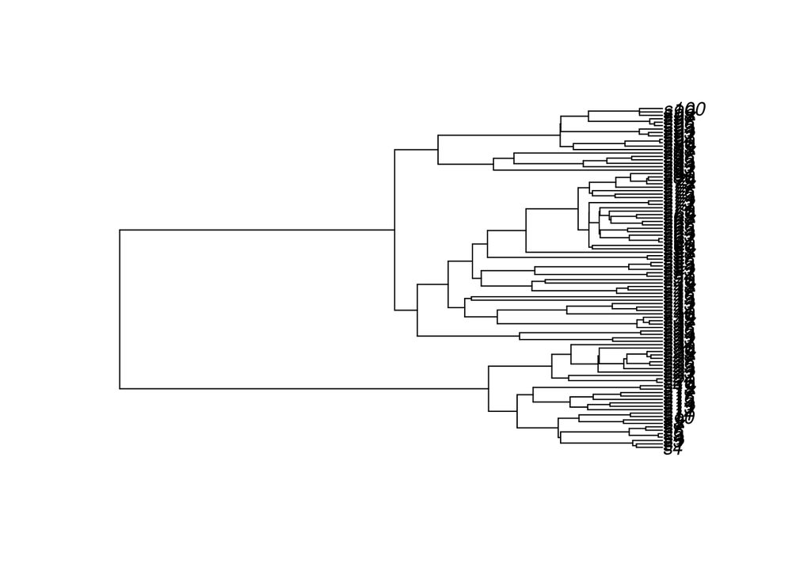

```r
ntaxa <- 100
set.seed(1)
tree <- sim.bdtree(b=1, stop="taxa", n=ntaxa)
tree$edge.length <- tree$edge.length/max(branching.times(tree))
plot(tree)
```

Set up the covariance matrix for changes in the underlying liabilities. Choose the values you want to use below. Remember the matrix must be positive definite (how do you check?)

```r
covAB <- 0.4
covAC <- 0.8
covBC <- -0.2
R <- matrix(c(  1,   covAB, covAC,
              covAB,     1, covBC,
              covAC,  covBC,  1), ncol=3, nrow=3, byrow=TRUE)
colnames(R) <- rownames(R) <- c("A", "B", "C")
R
```

```
##     A    B    C
## A 1.0  0.4  0.8
## B 0.4  1.0 -0.2
## C 0.8 -0.2  1.0
```

```r
eigen(R)
```

```
## eigen() decomposition
## $values
## [1] 1.8278820 1.1569868 0.0151312
##
## $vectors
##            [,1]       [,2]       [,3]
## [1,] -0.7284743 -0.1415774  0.6702843
## [2,] -0.1931866 -0.8962517 -0.3992641
## [3,] -0.6572702  0.4203436 -0.6255455
```

Simulate the data using ‘sim.char()’.

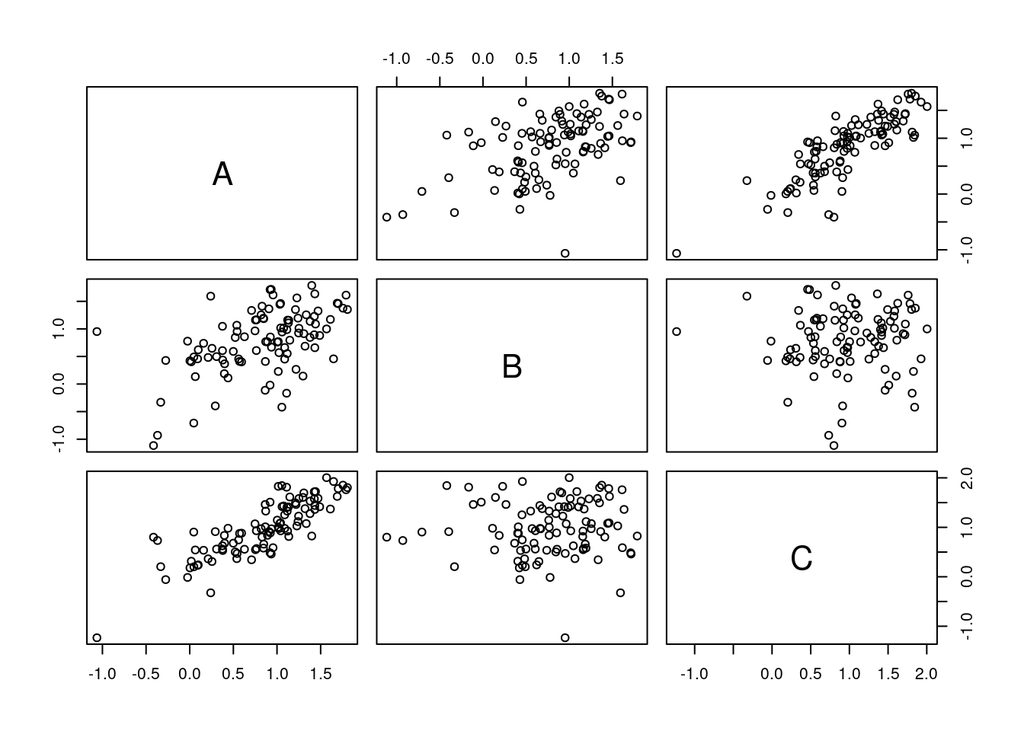

```r
dat <- sim.char(tree, par=R, nsim=1, model="BM")[,,1]
colnames(dat) <- c("A", "B", "C")
pairs(dat)
```

Match the tree and to the liabilities and create discretized variables.

```r
td <- make.treedata(tree, dat)
```

A pretty way to plot the liabilities:

```r
X <- as.matrix(td[c("A", "B", "C")])
rownames(X) <- td$phy$tip.label
fancyTree(td$phy, type="scattergram", X=X)
```

```
## Computing multidimensional phylogenetic scatterplot matrix...
```

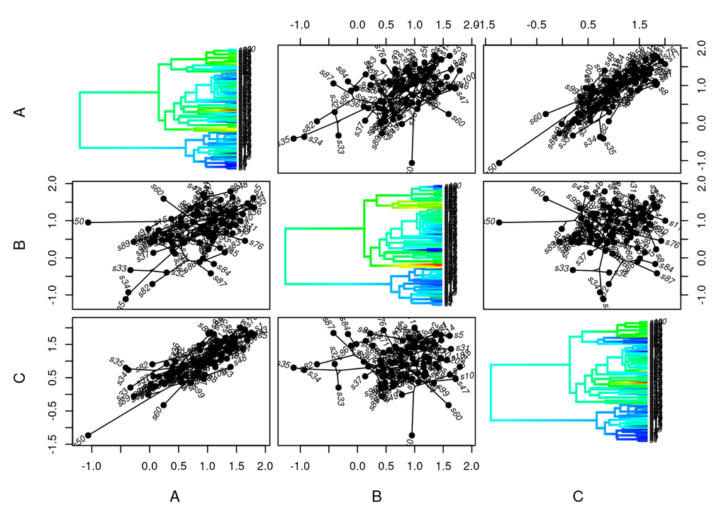

We now convert the liabilities into binary characters:

```r
td <- mutate(td, a = as.numeric(A > median(A)), b = as.numeric(B > median(B)), c = as.numeric(C > median(C)))
tree <- td$phy
traits <- as.data.frame(td$dat)
rownames(traits) <- td$phy$tip.label
```

Plot out the discrete traits:

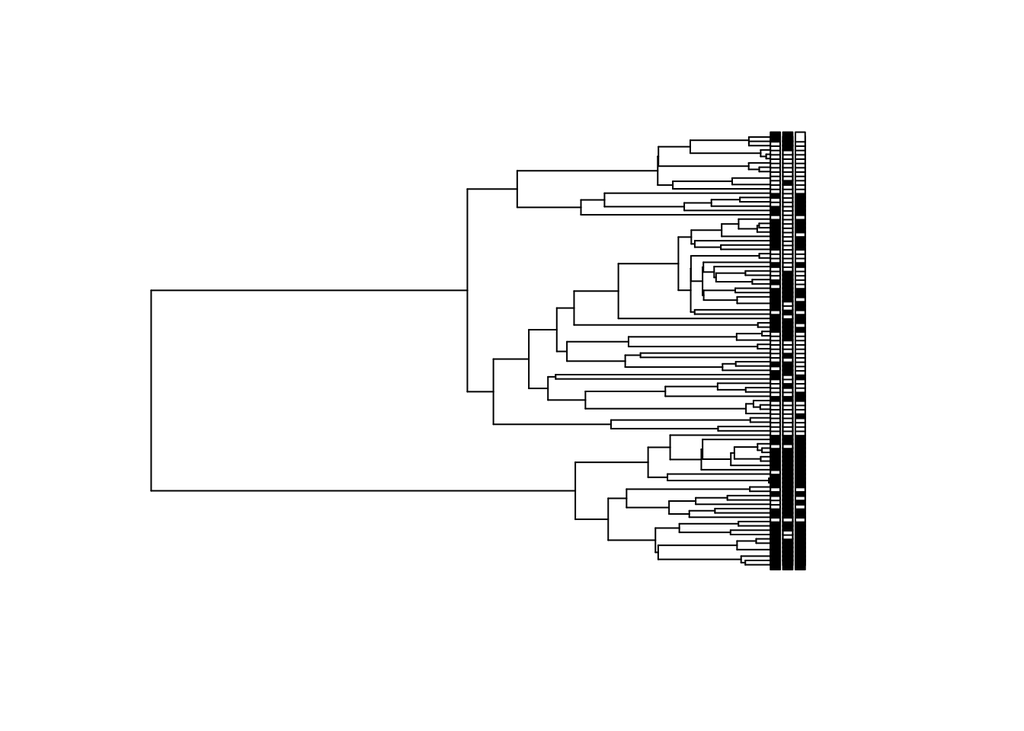

```r
par(mfrow=c(1,1))
plot(tree, show.tip.label=FALSE, x.lim = c(0,1.25))
tiplabels(pch=22, bg=traits[['a']])
tiplabels(pch=22, bg=traits[['b']], adj=c(0.52,0.5))
tiplabels(pch=22, bg=traits[['c']], adj=c(0.54,0.5))
```

# Option I. Phytools We’ll use phytools threshBayes function. I will rely heavily on Liam Revell’s tutorial for this, so all credit goes to him. His tutorial can be found here: http://www.phytools.org/eqg/Exercise_6.2/

```r
#First, we'll start with two continuous traits. For some reason this is especially slow in threshBayes, and you normally wouldn't use this software for two continuous traits anyways. We're only going to do so for comparison sake.
ngen <- 10000
X <- as.matrix(traits[,c('A', 'C')])
mod.AC <- threshBayes(tree, X, types=c("continuous", "continuous"), ngen=ngen, plot=FALSE, control=list(sample=1))
```

```
## Starting MCMC....
## generation: 1000; mean acceptance rate: 0.24
## generation: 2000; mean acceptance rate: 0.25
## generation: 3000; mean acceptance rate: 0.23
## generation: 4000; mean acceptance rate: 0.23
## generation: 5000; mean acceptance rate: 0.24
## generation: 6000; mean acceptance rate: 0.23
## generation: 7000; mean acceptance rate: 0.24
## generation: 8000; mean acceptance rate: 0.22
## generation: 9000; mean acceptance rate: 0.24
## generation: 10000; mean acceptance rate: 0.23
## Done MCMC.
```

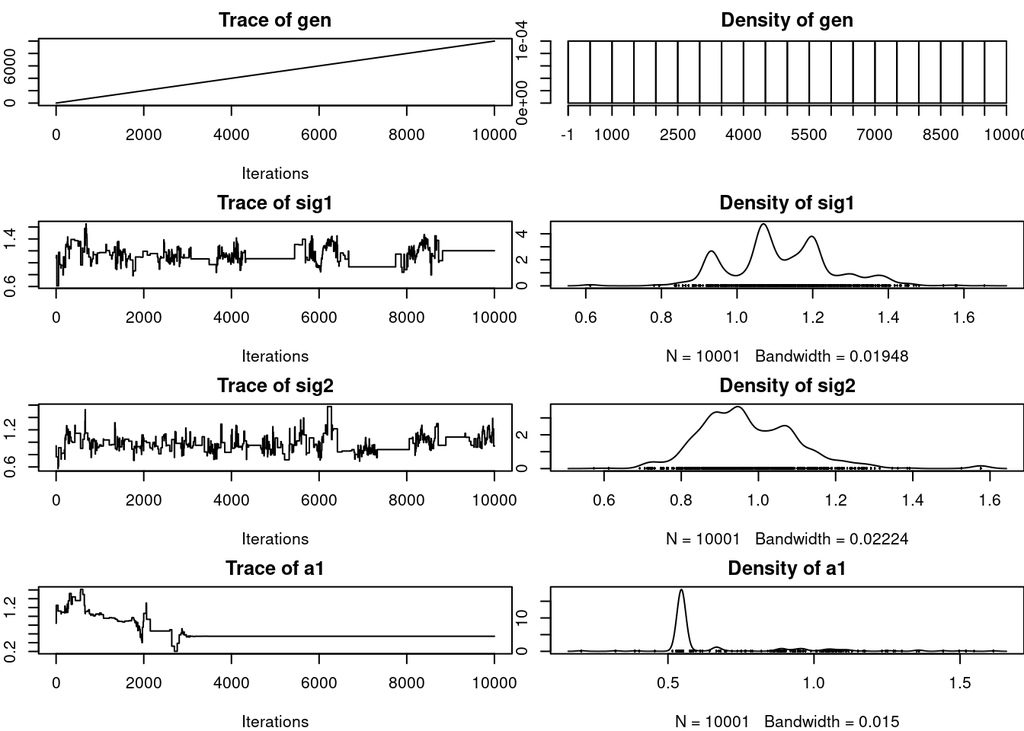

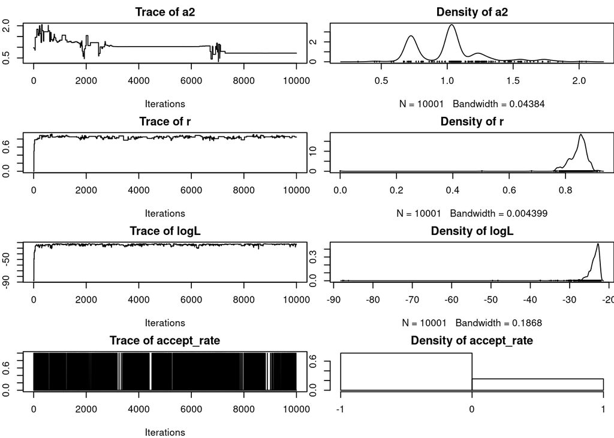

```r
mcmc.AC <- mcmc(mod.AC$par)
par(mfrow=c(3,2), mar=c(4,2,2,0))
plot(mcmc.AC)
```

```r
## Second, let's run one continuous trait (A) and one discrete trait (c):
X <- as.matrix(traits[,c('A', 'c')])
mod.Ac <- threshBayes(tree, X, types=c("continuous", "discrete"), ngen=ngen, plot=FALSE, control=list(sample=1))
```

```
## Starting MCMC....
## generation: 1000; mean acceptance rate: 0.21
## generation: 2000; mean acceptance rate: 0.21
## generation: 3000; mean acceptance rate: 0.2
## generation: 4000; mean acceptance rate: 0.18
## generation: 5000; mean acceptance rate: 0.19
## generation: 6000; mean acceptance rate: 0.19
## generation: 7000; mean acceptance rate: 0.2
## generation: 8000; mean acceptance rate: 0.19
## generation: 9000; mean acceptance rate: 0.2
## generation: 10000; mean acceptance rate: 0.21
## Done MCMC.
```

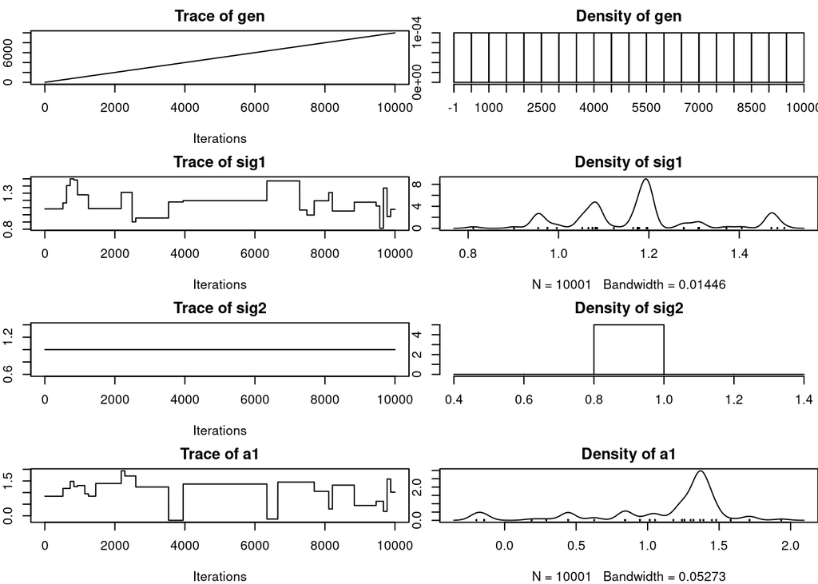

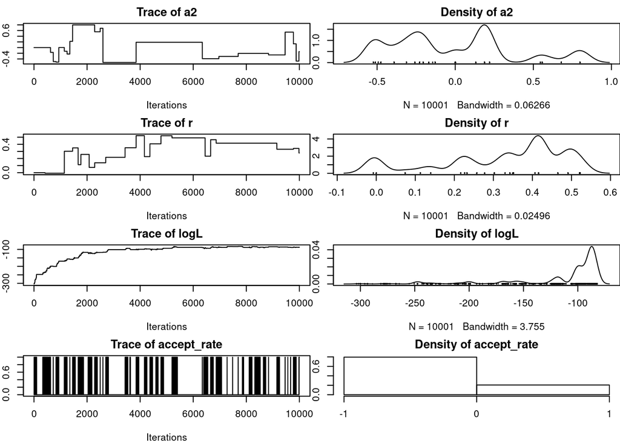

```r
mcmc.Ac <- mcmc(mod.Ac$par)
par(mfrow=c(3,2), mar=c(4,2,2,0))
plot(mcmc.Ac)
```

Now, change run again with both traits discrete:

```r
X <- as.matrix(traits[,c('a', 'c')])
mod.ac <- threshBayes(tree, X, types=c("discrete", "discrete"), ngen=ngen, plot=FALSE, control=list(sample=1))
```

```
## Starting MCMC....
## generation: 1000; mean acceptance rate: 0.3
## generation: 2000; mean acceptance rate: 0.19
## generation: 3000; mean acceptance rate: 0.13
## generation: 4000; mean acceptance rate: 0.18
## generation: 5000; mean acceptance rate: 0.23
## generation: 6000; mean acceptance rate: 0.24
## generation: 7000; mean acceptance rate: 0.24
## generation: 8000; mean acceptance rate: 0.23
## generation: 9000; mean acceptance rate: 0.22
## generation: 10000; mean acceptance rate: 0.2
## Done MCMC.
```

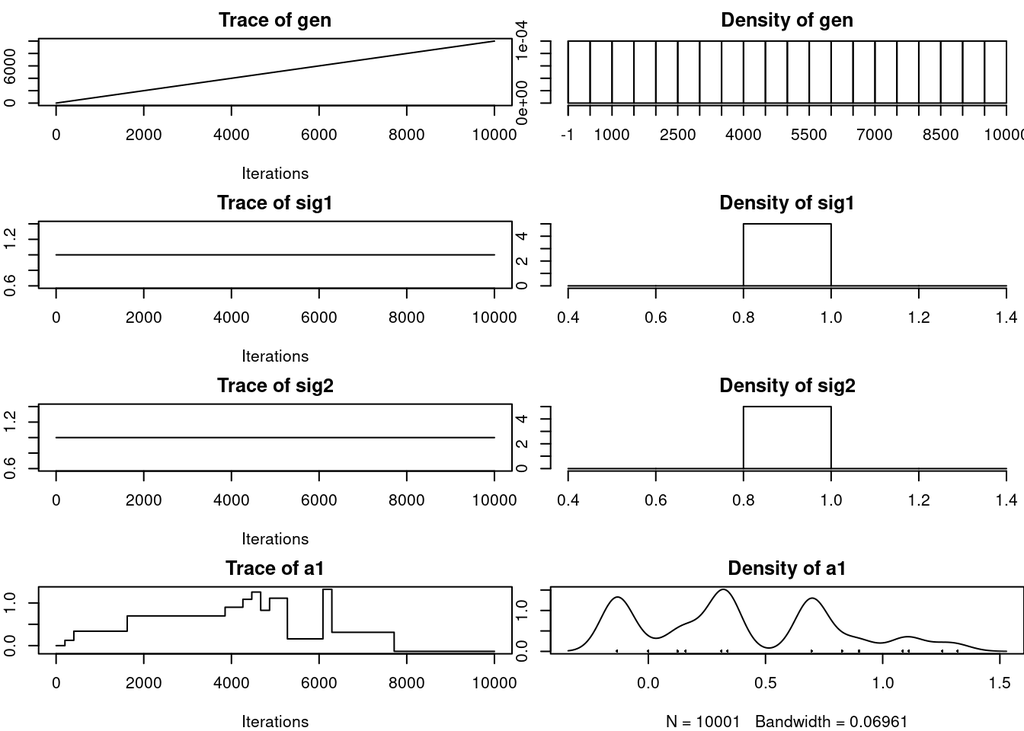

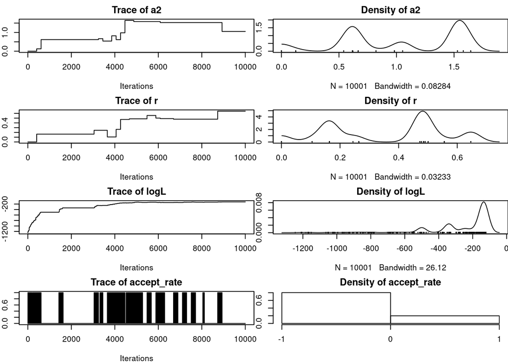

```r
mcmc.ac <- mcmc(mod.ac$par)
par(mfrow=c(3,2), mar=c(4,2,2,0))
plot(mcmc.ac)
```

In all cases, the correlations should be the same. What happens? What is the result of discretization on our estimate of the correlation?

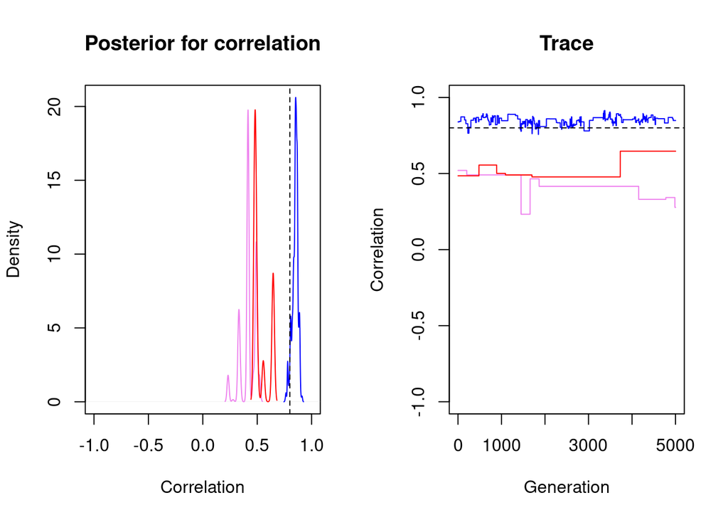

```r
par(mfrow=c(1,2))
postburnin <- floor(0.5*ngen):nrow(mcmc.AC)
plot(density(mcmc.AC[postburnin,'r']), type='n', main="Posterior for correlation", xlab= "Correlation", xlim=c(-1,1))
lines(density(mcmc.AC[postburnin,'r']), col="blue")
lines(density(mcmc.Ac[postburnin,'r']), col="violet")
lines(density(mcmc.ac[postburnin,'r']), col="red")
abline(v=covAC, lty=2)

plot(0,0, type="n", main="Trace", xlab= "Generation", ylab="Correlation", ylim=c(-1,1), xlim=c(0, length(postburnin)))
lines(mcmc.AC[postburnin,'r'], col="blue")
lines(mcmc.Ac[postburnin,'r'], col="violet")
lines(mcmc.ac[postburnin,'r'], col="red")
abline(h=covAC, lty=2)
```

# Option II. MCMCglmmRAM

Jarrod Hadfield has developed an efficient algorithm for estimating the threshold model using GLMM’s. This is essentially the same as our animal model from quantitative genetics What is the comparative analog to additive genetic variance? To a pedigree? Look at the prior (maybe go back to Pat Carter’s tutorial on MCMCglmm). What assumption is being made about residual variation? If you are running windows, you may need Rtools (https://cran.r-project.org/bin/windows/Rtools/) and if you are running Mac, you will need Xcode (https://www.moncefbelyamani.com/how-to-install-xcode-homebrew-git-rvm-ruby-on-mac/).

```r
# Make sure the file is in your working directory
install.packages("./MCMCglmmRAM_2.24.tar.gz", repos=NULL, type="source")
library(MCMCglmmRAM)
```

The data frame must have a column named “animal” and it MUST BE A FACTOR (not character).

```r
traits$animal <- factor(tree$tip.label)
traits
```

```
##                 A           B           C a b c animal
## s1    1.755860612  1.37638315  1.85238381 1 1 1     s1
## s2    1.251388935  1.01150502  1.58213559 1 1 1     s2
## s3    1.806540384  1.35257929  1.80366480 1 1 1     s3
## s4    1.701247933  1.45784598  1.78359545 1 1 1     s4
## s5    1.791155460  1.61254574  1.75946699 1 1 1     s5
## s6    1.441071003  1.08833630  1.72324610 1 1 1     s6
## s7    1.428174668  1.22866875  1.57587369 1 1 1     s7
## s8    1.014560729  0.22824585  1.82835353 1 0 1     s8
## s9    1.146561459  0.79544156  1.61341935 1 0 1     s9
## s10   1.211493066  1.35092108  1.49400308 1 1 1    s10
## s11   1.567859331  0.99932149  2.00425018 1 1 1    s11
## s12   0.158956132  0.73920189  0.53580908 0 0 0    s12
## s13   1.075917620  1.01586638  1.43201315 1 1 1    s13
## s14   1.689842032  1.46605718  1.62471136 1 1 1    s14
## s15   0.375228524  1.04755640  0.62580373 0 1 0    s15
## s16   0.817998397  1.25451095  0.97167653 0 1 1    s16
## s17   0.828864515  1.41221342  0.80390666 0 1 0    s17
## s18   1.227717747  1.56211365  1.02774978 1 1 1    s18
## s19   0.907299529  1.36396873  0.91412347 0 1 0    s19
## s20   1.041023360  1.46156676  1.08865190 1 1 1    s20
## s21   1.033143050  1.44554421  1.07991076 1 1 1    s21
## s22   1.470327054  1.32573508  1.58556457 1 1 1    s22
## s23   0.748332474  0.96464633  1.07043130 0 1 1    s23
## s24   1.130486729  1.10879555  1.41263045 1 1 1    s24
## s25   1.307516533  0.91384105  1.69567225 1 1 1    s25
## s26   1.379401064  1.13707685  1.53024531 1 1 1    s26
## s27   1.113310759  0.98692117  1.40171898 1 1 1    s27
## s28   1.058015830  0.94369363  1.41820582 1 1 1    s28
## s29   0.870694926  0.76784854  1.32798092 0 0 1    s29
## s30   1.426669402  0.89348217  1.71767207 1 1 1    s30
## s31   1.433314913  1.63541617  1.36172369 1 1 1    s31
## s32   0.293025815 -0.39685886  0.91257488 0 0 0    s32
## s33  -0.332123262 -0.33046023  0.20392314 0 0 0    s33
## s34  -0.368593673 -0.92949420  0.73270053 0 0 0    s34
## s35  -0.414698900 -1.11543252  0.80011113 0 0 0    s35
## s36   0.438714793  0.11084780  0.98071023 0 0 1    s36
## s37   0.064051417  0.13440922  0.54176729 0 0 0    s37
## s38   0.399763625  0.36685086  0.67872468 0 0 0    s38
## s39   0.594257504  0.40178720  0.88170418 0 0 0    s39
```

[output cut: 46 more lines]

```
## s86   0.864503572 -0.11260140  1.46199209 0 0 1    s86
## s87   1.055601591 -0.41955589  1.84368992 1 0 1    s87
## s88   0.090549261  0.45716945  0.23115607 0 0 0    s88
## s89  -0.274912838  0.42815703 -0.05783582 0 0 0    s89
## s90   0.542934950  0.95345999  0.47096798 0 1 0    s90
## s91   0.521688113  0.84452848  0.50232376 0 0 0    s91
## s92   0.396709299  0.18824045  0.83599003 0 0 0    s92
## s93   0.018056522  0.40389731  0.31391014 0 0 0    s93
## s94   0.307591405  0.49788151  0.56015285 0 0 0    s94
## s95   0.047674220  0.49093008  0.20158892 0 0 0    s95
## s96   0.002739021  0.42116593  0.17959142 0 0 0    s96
## s97   0.255191042  0.64816142  0.30806136 0 0 0    s97
## s98   0.539478377  1.06635615  0.36656010 0 1 0    s98
## s99   0.708625457  1.33479268  0.34335926 0 1 0    s99
## s100  0.933707654  1.71688241  0.45978274 1 1 0   s100
```

Now we are going to set our prior on the model. The R structure is the set to be essentially 0, because we are assuming no environmental effects. We then put in inverse-Wishart distribution on the G-structure, which will control our liabilities.

First, we will estimate covariances between our continuous traits.

```r
prior1 <- list(R=list(V=diag(2)*1e-15, fix=1), G=list(G1=list(V=diag(2), nu=0.002)))
mglmm.AC <- MCMCglmm(cbind(A, C)~trait-1, random=~us(trait):animal, rcov=~us(trait):units,
                     pedigree=tree, reduced=TRUE, data=traits, prior=prior1,
                     pr=TRUE, pl=TRUE, family=c("gaussian", "gaussian"), thin=1)
```

```
##
##                       MCMC iteration = 0
##
##                       MCMC iteration = 1000
##
##                       MCMC iteration = 2000
##
##                       MCMC iteration = 3000
##
##                       MCMC iteration = 4000
##
##                       MCMC iteration = 5000
##
##                       MCMC iteration = 6000
##
##                       MCMC iteration = 7000
##
##                       MCMC iteration = 8000
##
##                       MCMC iteration = 9000
##
##                       MCMC iteration = 10000
##
##                       MCMC iteration = 11000
##
##                       MCMC iteration = 12000
##
##                       MCMC iteration = 13000
```

```r
summary(mglmm.AC)
```

```
##
##  Iterations = 3001:13000
##  Thinning interval  = 1
##  Sample size  = 10000
##
##  DIC: 263.2367
##
##  G-structure:  ~us(trait):animal
##
##                      post.mean l-95% CI u-95% CI eff.samp
## traitA:traitA.animal    1.1256   0.8217    1.456     3158
## traitC:traitA.animal    0.8939   0.6327    1.177     3050
## traitA:traitC.animal    0.8939   0.6327    1.177     3050
## traitC:traitC.animal    0.9788   0.7148    1.260     3060
##
##  R-structure:  ~us(trait):units
##
##                     post.mean l-95% CI u-95% CI eff.samp
## traitA:traitA.units    1.1256   0.8217    1.456     3158
## traitC:traitA.units    0.8939   0.6327    1.177     3050
## traitA:traitC.units    0.8939   0.6327    1.177     3050
## traitC:traitC.units    0.9788   0.7148    1.260     3060
##
##  Location effects: cbind(A, C) ~ trait - 1
##
##        post.mean l-95% CI u-95% CI eff.samp  pMCMC
## traitA   0.80334 -0.34081  2.03885    10000 0.1816
## traitC   1.06334 -0.01059  2.22342    10000 0.0594 .
## ---
## Signif. codes:  0 '***' 0.001 '**' 0.01 '*' 0.05 '.' 0.1 ' ' 1
```

Now let’s estimate the correlation for the continuous version of ‘A’ and the discrete version of ‘c’. Note the changes from the previous code in the comments:

```r
prior2 <- list(R=list(V=diag(2)*1e-15, fix=1), G=list(G1=list(V=diag(2), nu=0.002, fix=2))) # We set fix=2 to fix the lower submatrix starting at row 2
mglmm.Ac <- MCMCglmm(cbind(A, c)~trait-1, random=~us(trait):animal, rcov=~us(trait):units,
                     pedigree=tree, reduced=TRUE, data=traits, prior=prior2,
                     pr=TRUE, pl=TRUE, family=c("gaussian","threshold"), thin=1) #We set the second trait to a threshold trait.
```

```
##
##                       MCMC iteration = 0
##
##                       MCMC iteration = 1000
##
##                       MCMC iteration = 2000
##
##                       MCMC iteration = 3000
##
##                       MCMC iteration = 4000
##
##                       MCMC iteration = 5000
##
##                       MCMC iteration = 6000
##
##                       MCMC iteration = 7000
##
##                       MCMC iteration = 8000
##
##                       MCMC iteration = 9000
##
##                       MCMC iteration = 10000
##
##                       MCMC iteration = 11000
##
##                       MCMC iteration = 12000
##
##                       MCMC iteration = 13000
```

```r
summary(mglmm.Ac)
```

```
##
##  Iterations = 3001:13000
##  Thinning interval  = 1
##  Sample size  = 10000
##
##  DIC: 248.2939
##
##  G-structure:  ~us(trait):animal
##
##                      post.mean l-95% CI u-95% CI eff.samp
## traitA:traitA.animal    1.1153   0.8150    1.442    528.8
## traitc:traitA.animal    0.9227   0.7382    1.129    252.2
## traitA:traitc.animal    0.9227   0.7382    1.129    252.2
## traitc:traitc.animal    1.0000   1.0000    1.000      0.0
##
##  R-structure:  ~us(trait):units
##
##                     post.mean l-95% CI u-95% CI eff.samp
## traitA:traitA.units    1.1153   0.8150    1.442    528.8
## traitc:traitA.units    0.9227   0.7382    1.129    252.2
## traitA:traitc.units    0.9227   0.7382    1.129    252.2
## traitc:traitc.units    1.0000   1.0000    1.000      0.0
##
##  Location effects: cbind(A, c) ~ trait - 1
##
##        post.mean l-95% CI u-95% CI eff.samp pMCMC
## traitA   0.80090 -0.33591  2.01692    10000 0.175
## traitc  -0.02537 -1.13090  1.11996     7674 0.970
```

Now we do a fully threshold model with two binary traits. We use the helper function “corg” to fix the estimated covariance matrix to be a correlation matrix.

```r
prior3 <- list(R=list(V=diag(2)*1e-15, fix=1), G=list(G1=list(V=diag(2), nu=0.002))) #Fix is no longer needed because we are using the "corg" auxilliary functions below to fix the variances for both traits.
mglmm.ac <- MCMCglmm(cbind(a, c)~trait-1, random=~corg(trait):animal, rcov=~corg(trait):units, #Note that we use "corg" instead of "us"
                     pedigree=tree, reduced=TRUE, data=traits, prior=prior3,
                     pr=TRUE, pl=TRUE, family=c("threshold", "threshold"), thin=1)
```

[output not shown]

```r
summary(mglmm.ac)
```

```
##
##  Iterations = 3001:13000
##  Thinning interval  = 1
##  Sample size  = 10000
##
##  DIC:
##
##  G-structure:  ~corg(trait):animal
##
##                      post.mean l-95% CI u-95% CI eff.samp
## traita:traita.animal    1.0000   1.0000   1.0000     0.00
## traitc:traita.animal    0.9698   0.8768   0.9998    38.71
## traita:traitc.animal    0.9698   0.8768   0.9998    38.71
## traitc:traitc.animal    1.0000   1.0000   1.0000     0.00
##
##  R-structure:  ~corg(trait):units
##
##                     post.mean l-95% CI u-95% CI eff.samp
## traita:traita.units    1.0000   1.0000   1.0000     0.00
## traitc:traita.units    0.9698   0.8768   0.9998    38.71
## traita:traitc.units    0.9698   0.8768   0.9998    38.71
## traitc:traitc.units    1.0000   1.0000   1.0000     0.00
##
##  Location effects: cbind(a, c) ~ trait - 1
##
##        post.mean l-95% CI u-95% CI eff.samp pMCMC
## traita  -0.01041 -1.11499  1.11563     5568 0.986
## traitc   0.06337 -1.04084  1.17990     5331 0.918
```

Let’s plot out the estimated covariances against their true values:

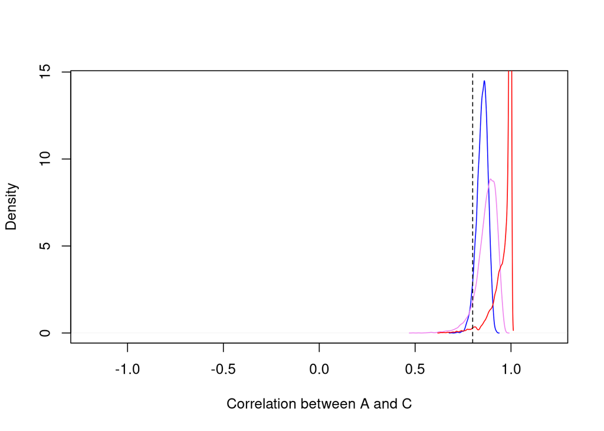

```r
plot(density(mglmm.AC$VCV[,2]/sqrt(mglmm.AC$VCV[,1]*mglmm.AC$VCV[,4])), type="n", main="", xlim=c(-1.2,1.2), ylab="Density", xlab="Correlation between A and C")

lines(density(mglmm.AC$VCV[,2]/sqrt(mglmm.AC$VCV[,1]*mglmm.AC$VCV[,4])), col="blue")
lines(density(mglmm.Ac$VCV[,2]/sqrt(mglmm.Ac$VCV[,1]*mglmm.Ac$VCV[,4])), col="violet")
lines(density(mglmm.ac$VCV[,2]), col="red") #Variances are fixed to 1, so covariance = correlation
abline(v=covAC, lty=2)
```

Notice that we said pr=TRUE and pl=TRUE. This saves the posterior distribution of random effects and latent variables, respectively, so that we can recover the estimated liabilities at the nodes. First, let’s get the liabilities at the tips:

```r
postburnin <- floor(0.3*nrow(mglmm.ac$Liab)):nrow(mglmm.ac$Liab)
a.liab <- apply(mglmm.ac$Liab[postburnin,1:ntaxa], 2, mean)
c.liab <- apply(mglmm.ac$Liab[postburnin,(ntaxa+1):(2*ntaxa)], 2, mean)
```

Now plot the liabilities against their true values.

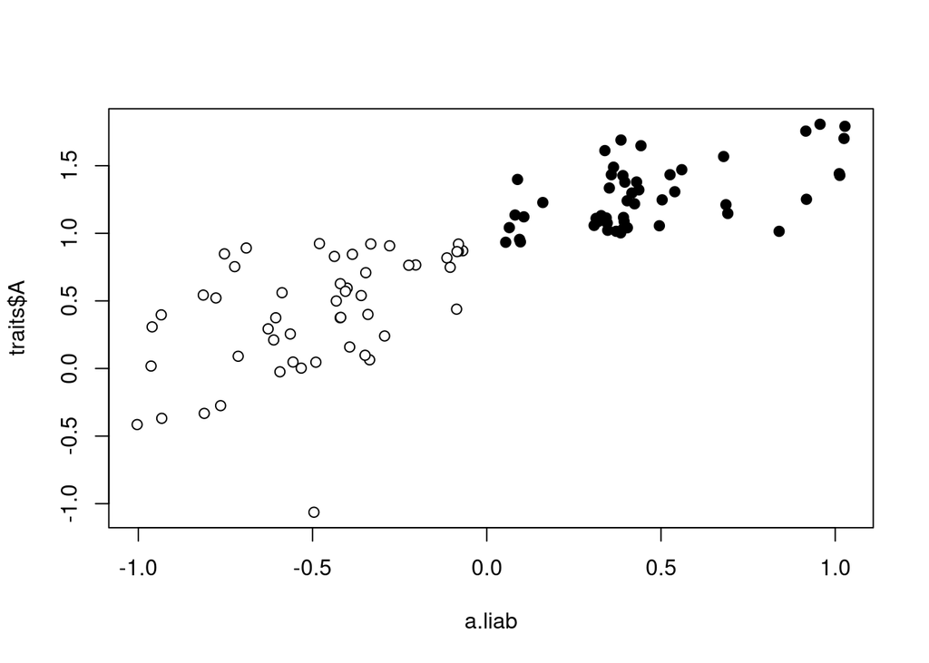

```r
plot(a.liab, traits$A, pch=21,  bg=traits$a)
```

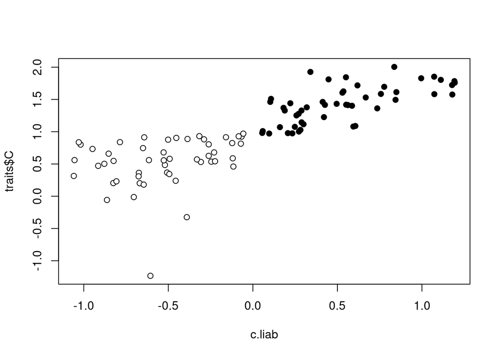

```r
plot(c.liab, traits$C, pch=21,  bg=traits$c)
```

Now get the liabilities at the nodes.

```r
a.nodeLiab <- apply(mglmm.ac$Sol[postburnin, 1:tree$Nnode], 2, mean)
```

And we can plot them on the tree:

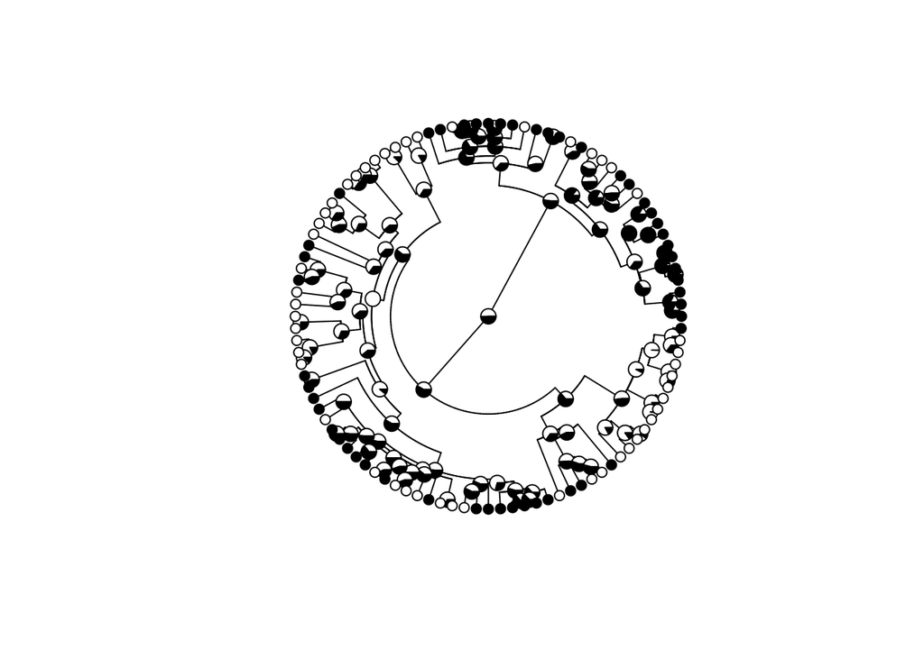

```r
plot(tree, type="fan", show.tip.label=FALSE)
a.pie <- (a.nodeLiab-min(a.nodeLiab))/diff(range(a.nodeLiab))
a.pie <- cbind(1-a.pie, a.pie)
nodelabels(pie=a.pie, piecol = c("white", "black"), cex=0.5)
tiplabels(pch=21, bg = c("white", "black")[traits$a+1])
```

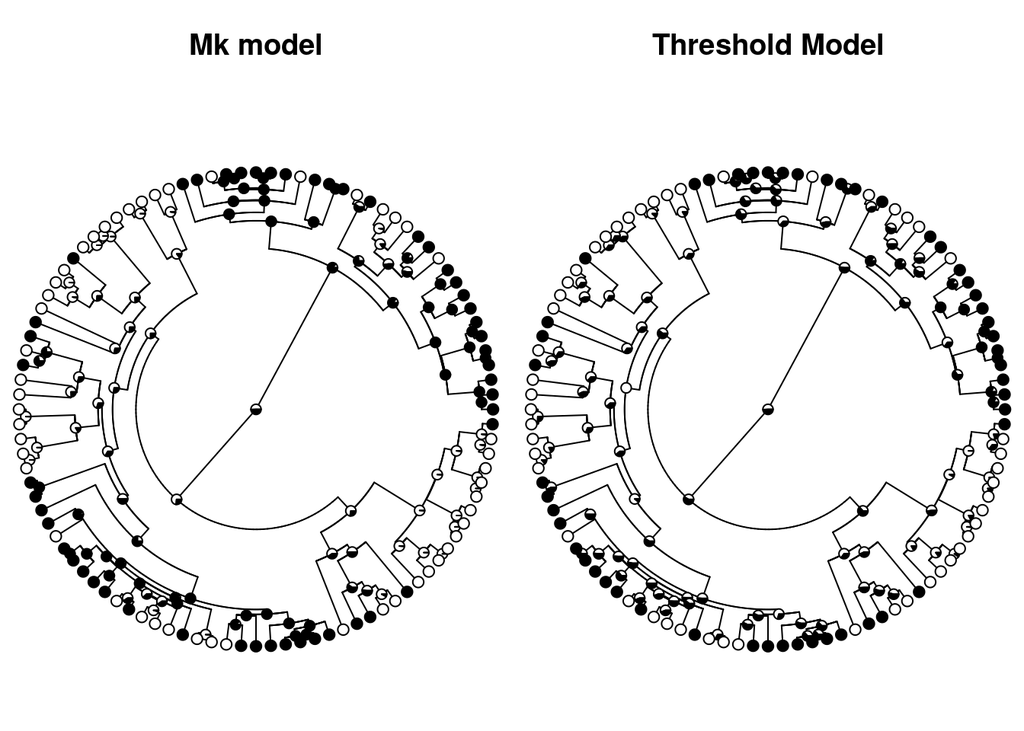

```r
mk.asr <- ace(traits$a, phy=tree, type="discrete")

par(mfrow=c(1,2), mar=c(0,0,3,0))
plot(tree, type="fan", show.tip.label=FALSE, main="Mk model")
mk.pie <- mk.asr$lik.anc
nodelabels(pie=mk.pie, piecol = c("white", "black"), cex=0.5)
tiplabels(pch=21, bg = c("white", "black")[traits$a+1])

plot(tree, type="fan", show.tip.label=FALSE, main="Threshold Model")
nodelabels(pie=a.pie, piecol = c("white", "black"), cex=0.5)
tiplabels(pch=21, bg = c("white", "black")[traits$a+1])
```

How are they different? Why might it matter whether you model a trait as a threshold trait, or a traditional discrete trait in a Markov model, like DNA?